# Homework 3

Innocent Abaa

2023-09-11

# 1 Exercise 3.10

Prove that the algorithm given in Exercise 3.9 generates variates from the density $f_{e}$.

The algorithm can be expressed as follows: Start by generating three independent and identically distributed (i.i.d.) random variables, denoted as $Y_1$, $Y_2$, and $Y_3$, from a uniform distribution in the range $(0, 1)$.

Now, consider $Y_3$, and if it happens to be the largest value among the three, set $Y$ equal to $Y_2$. However, if $Y_3$ is not the largest value, then $Y$ takes on the value of $Y_3$. In essence, $Y$ represents either the first or second largest value among the sample $Y_1$, $Y_2$, and $Y_3$.

Finally, the algorithm produces an outcome $T$, which is either $Y$ or $-Y$, each with an equal probability of $1/2$.

Notice that the cdf of the $k^{\text {th }}$ order statistic is given by

$$F_{Y_{(r)}}(x) = \sum_{j=r}^{n} \binom{n}{j} [F_{Y}(y)]^{j}
[1-F_{Y}(y)]^{n-j}$$

when $n=3$

$$F_{Y_{(r)}}(y)=\sum_{j=r}^{3}\left(\begin{array}{l}
3 \\
j
\end{array}\right)\left[F\left(Y_{r}\right)\right]^{j}\left[1-F\left(Y_{r}\right)\right]^{3-j}
.$$

So we can compute the cdf of $Y$ as follows:

$$\begin{aligned}
F(Y) & =\frac{1}{2} F_{1}(Y)+\frac{1}{2} F_{2}(Y) \\
\end{aligned}$$

Here, $F_1(Y)$ represents the CDF of $Y_1$, and $F_2(Y)$ represents the CDF of $Y_2$.

$$F_1(Y) = 1 - \text{Probability}(Y_1 > Y) = 1 -
\text{Probability}(Y_2 > Y, Y_3 > Y)$$

Since $Y_2$ and $Y_3$ are independent and identically distributed random variables,

$$F_1(Y) = 1 - \text{Probability}(Y_2 > Y) \cdot
\text{Probability}(Y_3 > Y)$$

For a random variable $X$ following a Uniform(0,1) distribution, its CDF is $F_X(x) = x$ for $0 \leq x \leq 1$. Applying this to $Y_2$ and $Y_3$:

- $F_{Y_2}(Y) = Y$
- $F_{Y_3}(Y) = Y$

$$F_1(Y) = 1 - Y \cdot Y = 1 - Y^2$$

$$F(Y) = \frac{1}{2} F_1(Y) + \frac{1}{2} F_2(Y) = \frac{1}{2}(1 - Y^2)
+ \frac{1}{2} F_2(Y)$$

$$F_2(Y) = 1 - \text{Probability}(Y_1 > Y, Y_3 > Y)$$

Differentiating the cdf above will give us the density of $Y$ as

$$f(y)=\frac{dF(y)}{dy}=\frac{1}{2}\left(3-3
y^{2}\right)=\frac{3}{2}\left(1-y^{2}\right), \quad 0<y<1 .$$

The density function above is not exactly as we have in exercise 3.9.So, multiply f(y) by $\frac{1}{2}$ will give $f_{e}(y)$.

Thus, replacing y as t, will yield our desired results as below;

$$f_{e}(t)=\frac{1}{2} \times
\frac{3}{2}\left(1-t^{2}\right)=\frac{3}{4}\left(1-t^{2}\right),
\quad|t|\leq 1,$$

$\textbf{Comment}$

The pdf of the algorithm in exercise 3.10 is the same as the pdf in exercise 3.9. Thus, prove

# 2 Exercise 3.11

Generate a random sample of size 1000 from a normal location mixture.The components of the mixture have $N(0, 1)$ and $N(3, 1)$ distributions with mixing probabilities $p_1$ and $p_2 = 1 − p_1$. Graph the histogram of the sample with density superimposed, for $p_1 = 0.75$. Repeat with different values for $p_1$ and observe whether the empirical distribution of the mixture appears to be bimodal. Make a conjecture about the values of $p_1$ that produce bimodal mixtures.

```r
# Generate data (same as in the previous code)
n <- 1000
p1 <- 0.75
mu <- sample(c(0, 3), size = n, replace = TRUE, prob = c(p1, 1 - p1))
x <- rnorm(n, mean = mu, sd = 1)
```

We graph the histogram of the sample with density superimposed, when $p_1=0.75$

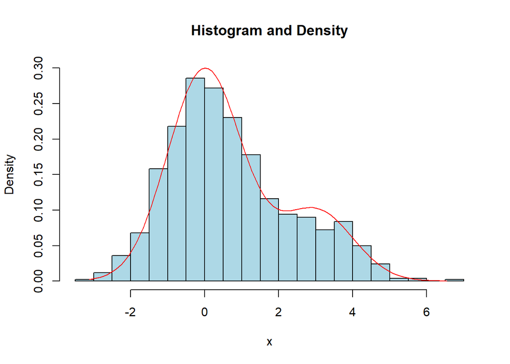

```r
# Create a histogram
# Calculate the range and sequence of y-axis values
y_min <- 0.00
y_max <- 0.30
y_increment <- 0.05
y_values <- seq(y_min, y_max, by = y_increment)
hist(x, probability = TRUE, col = "lightblue", breaks = 30, main = "Histogram and Density",ylim = range(y_values))

# Define the density function
fy <- function(y, p) {
  p * dnorm(y) + (1 - p) * dnorm(y, 3, 1)
}

# Generate x values for the curve
x_values <- seq(min(x), max(x), length.out = 100)

# Evaluate the density function for x_values
density_values <- fy(x_values, p1)

# Overlay the density curve
lines(x_values, density_values, col = "red", lwd = 1)
```

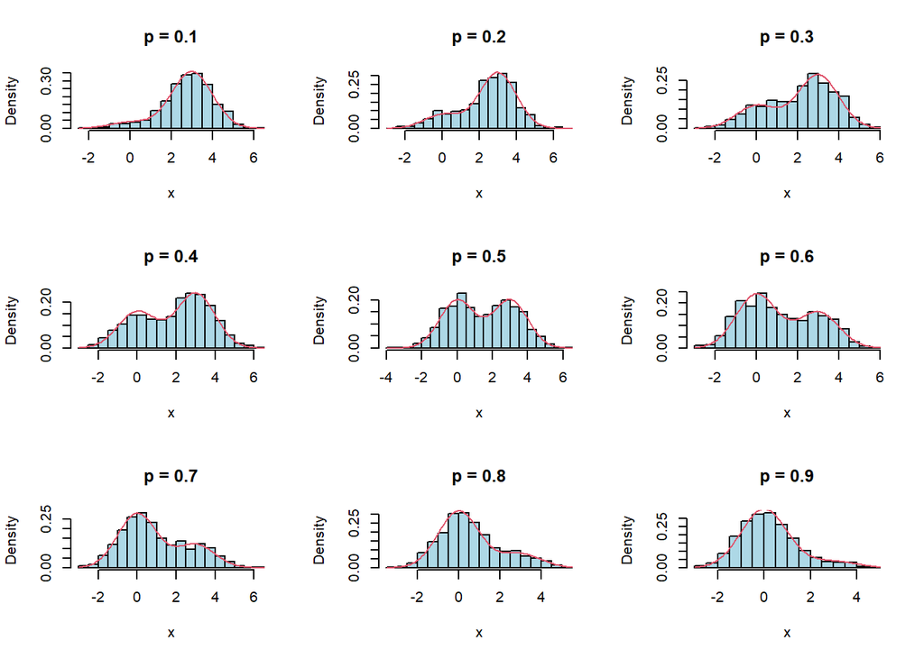

```r
# Set up the plotting layout
par(mfrow = c(3, 3))

# Define a sequence of values for p
p <- seq(.1, .9, length = 9)

# Create a list to store the generated data
data_list <- lapply(p, function(p_val) {
  mu <- sample(c(0, 3), size = 1000, replace = TRUE, prob = c(p_val, 1 - p_val))
  x <- rnorm(1000, mu, 1)
  list(mu = mu, x = x)
})

# Define the density function
fy <- function(y, p) {
  p * dnorm(y) + (1 - p) * dnorm(y, 3, 1)
}

# Loop through the data and plot histograms with density curves
for (i in 1:9) {
  mu <- data_list[[i]]$mu
  x <- data_list[[i]]$x

  # Create a histogram with Scott's rule for bin width
  hist(x, breaks = "Scott",col = "lightblue", prob = TRUE,
       main = paste("p =", p[i]))

  # Overlay the density curve on the histogram
  curve(fy(x, p[i]), add = TRUE, col = 2)
}
```

$\textbf{Comment}$

From graphs we can make conjecture that the empirical distribution of the mixture is bimodal for $p_1$ values close to $0.5$ . The mixture appears to be bimodal for $0.2 < p_1 <0.8$. The distribution is skewed and unimodal when $p_1$ is close to $1$ or $0$.

# 3 Exercise 3.12

Simulate a continuous Exponential-Gamma mixture. Suppose that the rate parameter Λ has Gamma(r, β) distribution and Y has Exp(Λ) distribution. That is, $(Y |Λ = λ) ∼ f_Y (y|λ) = λe^{−λy}$. Generate 1000 random observations from this mixture with r = 4 and β = 2.

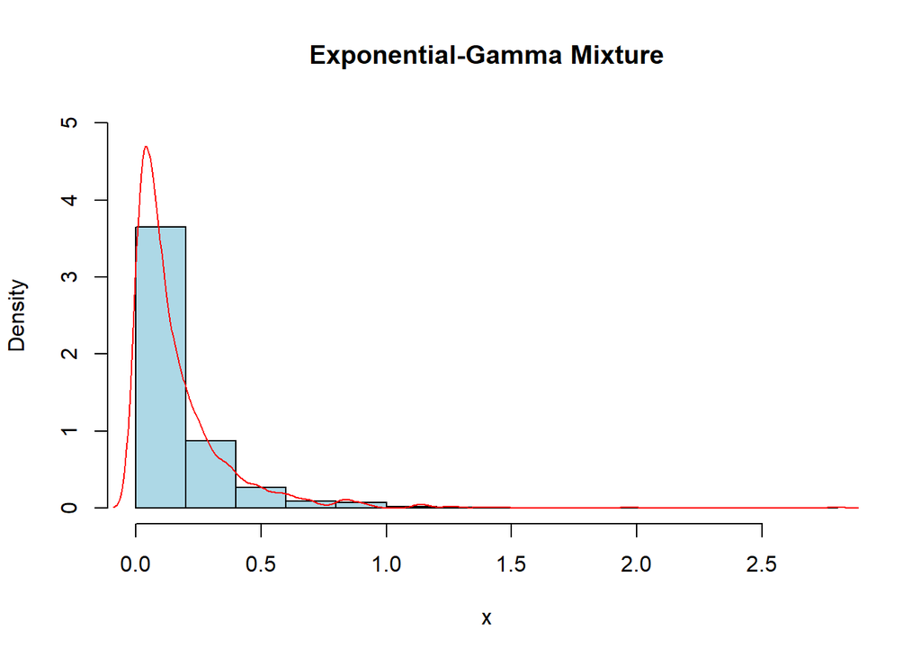

```r
# Set the number of data points
n <- 1000

# Set the shape parameter for the gamma distribution
r <- 4

# Set the scale parameter for the gamma distribution
beta <- 2

# Generate random values for lambda from a gamma distribution
lambda <- rgamma(n, shape = r, scale = beta)

# Generate random values for x from an exponential distribution
x <- rexp(n, rate = lambda)

# Set up the plotting parameters
par(mfrow = c(1, 1))

# Create a histogram
hist(x, probability = TRUE, col = "lightblue", main = "Exponential-Gamma Mixture", xlab = "x", ylim = c(0, 5))

# Add a density plot
lines(density(x), col = "red", lwd = 1)
```

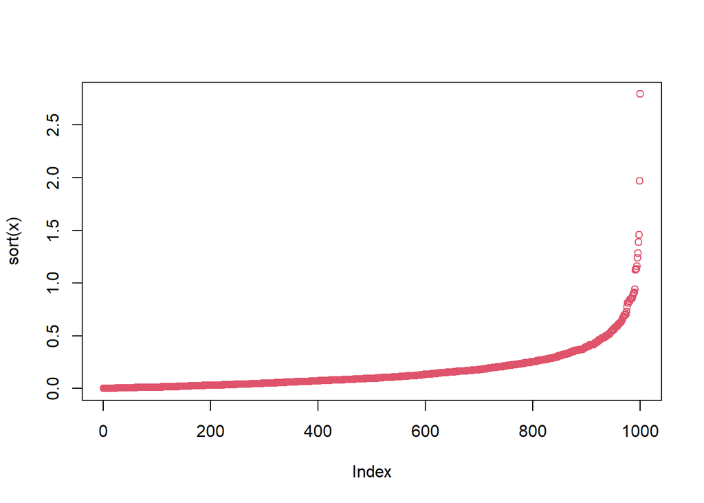

```r
# Create a sorted plot
plot(sort(x),col=2)
```

$\textbf{Comment}$

# 4 Exercise 3.13

It can be shown that the mixture in Exercise 3.12 has a Pareto distribution with cdf
$$F(y)=1-\left(\frac{\beta}{\beta+y}\right)^{r}, \quad y \geq 0 .$$
(This is an alternative parameterization of the Pareto cdf given in Exercise 3.3.) Generate 1000 random observations from the mixture with r = 4 and β = 2. Compare the empirical and theoretical (Pareto) distributions by graphing the density histogram of the sample and superimposing the Pareto density curve.

$\textbf{Solution}$

The Pareto density is

$$f(y)=F^{\prime}(y)=\frac{r \beta^{r}}{(\beta+y)^{r+1}}, \quad y \geq 0 .$$

$$U = 1 - \left(\frac{2}{2 +
X}\right)^4$$
Transforming U will give us:

$$X = \frac{2}{(1 - U)^{\frac{1}{4}}} -
2$$

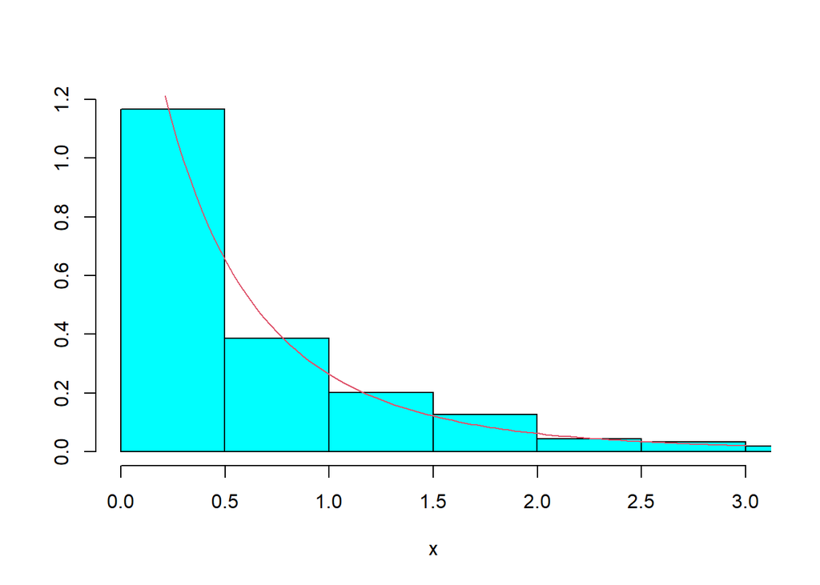

```r
# Set the number of observations
n <- 1000

# Generate random values from a uniform distribution
u <- runif(n)

# Transform u to obtain the variable x
x <- (2 / (1 - u)^(1/4)) - 2 # Transformation: U = 1 - (2 / (2 + X))^4, X = (2 / (1 - U)^(1/4)) - 2

MASS::truehist(x, xlim=c(0, quantile(x, .98)))
fy <- function(y, r) {
r * beta^r * (beta + y)^(-r - 1)
}
curve(fy(x, r), add=TRUE, col=2)
```